# Module 6 - Describing Data: Probability Sections 1 and 2

# Probability II

Probably. - Using sample data as a basis to answer questions about a population. - Relates samples and populations through populations and proportions. - Probability -> propotion of outcome

$$\textrm{probability of A} = \frac{\textrm{number of outcomes clased as
A}}{\textrm{total number of outcomes}}$$

Which means I need a dataset with a population.

# Probability and porportions

So let’s find the probability of one tree type being ‘selected’

```r
Area_Subset <- subset(covertype, covertype$wilderness_area4=="TRUE")
uniquetypes <- unique(covertype$cover_type)
treecount <- c(table(sort(covertype$cover_type)))

for(i in uniquetypes)
  {
      print(paste("Probability of selecting CoverType", i, " from Wilderness_Area4 is: ", (sum(treecount[i])/sum(treecount[1:7]))*100, sep=""))
  }
```

[output not shown]

Frequency Graphs:

```r
Area_Subset <- subset(covertype, covertype$wilderness_area4=="TRUE")
uniquetypes <- unique(covertype$cover_type)
treecount <- c(table(covertype$cover_type))
percentages <- c()
options(warn=-1)

for(i in sort(uniquetypes))
  {
    percentages <- append(percentages, sum(treecount[i])/sum(treecount[1:7])*100)
  }

par(mfrow=c(1,2))
barplot(treecount, main = "Simple Frequency")
barplot(percentages, main = "Probability Frequency?")

par(mfrow=c(2,2))
plot(dnorm(percentages), type = "l")
plot(pnorm(percentages), type = "l")
plot(qnorm(percentages), type = "l")
plot(rnorm(percentages), type = "l")

# Or should that be counts?
par(mfrow=c(1,1))
plot(rnorm(treecount), type = "l")

# If so only rnorm works for treecount and rnorm: "....is used to generate random numbers whose distribution is normal. It takes the sample size as input and generates that many random numbers. We draw a histogram to show the distribution of the generated numbers...."
# Making dnorm the only one that looks like the classic 'normal distribution'.
# But this all feels like incorrect categories...These are all counts and not values. What's the standard deviation for "yes" or "no"? That doesn't seem right.
options(warn=0)
```

[output not shown]

CoverType

1. Spruce/Fir
2. Lodgepole Pine
3. Ponderosa Pine
4. Cottonwood/Willow
5. Aspen
6. Douglas-fir
7. Krummholz

Wilderness area name:

1. Rawah
2. Neota
3. Comanche Peak
4. Cache la Poudre Wilderness Area

# Notations and Random Sampling

Expressed as fractions, decimals, or percentages.

# The Unit Normal Table

- Gives the probability that a standard normal random variable Z is less than any given number z.
- Used to find the probability that a statistic is observed below, above, or between values on the standard normal distribution, and by extension, any normal distribution.

# The Binomial Distribution

- When a variable is measured in a scale of two categories the resulting data is termed ‘binomial’.
- Off on, yes no.

**dbinom** (probability): returns the value of the probability density function

```
dbinom(x,             # X-axis values (x = 0, 1, 2, ..., n)
     size,            # Number of trials (n > = 0)
     prob,            # The probability of success on each trial
     log = FALSE)     # If TRUE, probabilities are given as log
```

```r
#So how does this fit in with the trees?
treecount <- c(table(sort(covertype$cover_type)))
chance <- (sum(treecount[2])/sum(treecount[1:7]))
dbi<-dbinom(x = 1000:2000, size = treecount, prob = chance)

plot(dbi, type = "h", lwd = 1,
     main = "Ranged 1000 to 2000, how likely are you to have x covertype? \n dbinom()",
     ylab = "P(X = x)", xlab = "X number of trees")

FileDirectory <- paste("/home/daiten/Programming/R/Projects/Biostatistics Tutorial/Media/", sep="")
png(paste(FileDirectory, "TreeProbability.jpg", sep = ""), width = 1000, height = 500)
```

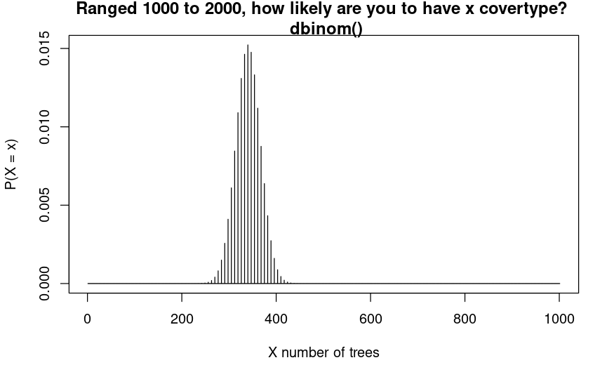

```r
plot(dbi, type = "h", lwd = 1,
     main = "Ranged 1000 to 2000, how likely are you to have x covertype? \n dbinom()",
     ylab = "P(X = x)", xlab = "X number of trees")
dev.off()
```

**pbinom** (distribution): returns the value of the cumulative density function

```
pbinom(q,             # Quantile or vector of quantiles
   size,              # Number of trials (n > = 0)
   prob,              # The probability of success on each trial
   lower.tail = TRUE, # If TRUE, probabilities are P(X <= x), or P(X > x) otherwise
   log.p = FALSE)     # If TRUE, probabilities are given as log
```

- Returns the area to the left of a (q) in the binomial distribution.
- Binomial distribution (Cumulative distribution function)

**qbinom** (quantile): returns the value of the inverse cumulative density function - Binomial quantile function

```
qbinom(p,                 # Probability or vector of probabilities
       size,              # Number of trials (n > = 0)
       prob,              # The probability of success on each trial
       lower.tail = TRUE, # If TRUE, probabilities are P(X <= x), or P(X > x) otherwise
       log.p = FALSE)     # If TRUE, probabilities are given as log
```

- Given a probability or a set of probabilities, obtains the corresponding binomial quantile.
- Find the pth quantile of a binomial distribution.

**rbinom** (random) - function allows drawing nn random samples from a binomial distribution in R. - Binomial pseudorandom number generation

```
rbinom(n,    # Number of random observations to be generated
       size, # Number of trials (> = 0)
       prob) # The probability of success on each trial
```

- generates a vector of binomial distributed random variables given a vector length n, number of trials (size) and probability of success on each trial (prob).
- draw nn random observations from a binomial distribution in R.

# Multiplication and Addition Rules